# spotify_final

```python
import numpy as np
import pandas as pd
import seaborn as sns
import matplotlib.pyplot as plt
import warnings
warnings.filterwarnings("ignore")
```

```python
df=pd.read_csv('spotify_dataset.csv')  # to read the dataset
```

```python
df
```

|  | Unnamed: 0 | track_id | artists | album_name | track_name | popularity | duration_ms | explicit | danceability | energy | ... | loudness | mode | speechiness | acousticness | instrumentalness | liveness | valence | tempo | time_signature | track_genre |
| --- | --- | --- | --- | --- | --- | --- | --- | --- | --- | --- | --- | --- | --- | --- | --- | --- | --- | --- | --- | --- | --- |
| 0 | 0 | 5SuOikwiRyPMVoIQDJUgSV | Gen Hoshino | Comedy | Comedy | 73 | 230666 | False | 0.676 | 0.4610 | ... | -6.746 | 0 | 0.1430 | 0.0322 | 0.000001 | 0.3580 | 0.7150 | 87.917 | 4 | acoustic |
| 1 | 1 | 4qPNDBW1i3p13qLCt0Ki3A | Ben Woodward | Ghost (Acoustic) | Ghost - Acoustic | 55 | 149610 | False | 0.420 | 0.1660 | ... | -17.235 | 1 | 0.0763 | 0.9240 | 0.000006 | 0.1010 | 0.2670 | 77.489 | 4 | acoustic |
| 2 | 2 | 1iJBSr7s7jYXzM8EGcbK5b | Ingrid Michaelson;ZAYN | To Begin Again | To Begin Again | 57 | 210826 | False | 0.438 | 0.3590 | ... | -9.734 | 1 | 0.0557 | 0.2100 | 0.000000 | 0.1170 | 0.1200 | 76.332 | 4 | acoustic |
| 3 | 3 | 6lfxq3CG4xtTiEg7opyCyx | Kina Grannis | Crazy Rich Asians (Original Motion Picture Sou... | Can't Help Falling In Love | 71 | 201933 | False | 0.266 | 0.0596 | ... | -18.515 | 1 | 0.0363 | 0.9050 | 0.000071 | 0.1320 | 0.1430 | 181.740 | 3 | acoustic |
| 4 | 4 | 5vjLSffimiIP26QG5WcN2K | Chord Overstreet | Hold On | Hold On | 82 | 198853 | False | 0.618 | 0.4430 | ... | -9.681 | 1 | 0.0526 | 0.4690 | 0.000000 | 0.0829 | 0.1670 | 119.949 | 4 | acoustic |
| ... | ... | ... | ... | ... | ... | ... | ... | ... | ... | ... | ... | ... | ... | ... | ... | ... | ... | ... | ... | ... | ... |
| 113995 | 113995 | 2C3TZjDRiAzdyViavDJ217 | Rainy Lullaby | #mindfulness - Soft Rain for Mindful Meditatio... | Sleep My Little Boy | 21 | 384999 | False | 0.172 | 0.2350 | ... | -16.393 | 1 | 0.0422 | 0.6400 | 0.928000 | 0.0863 | 0.0339 | 125.995 | 5 | world-music |
| 113996 | 113996 | 1hIz5L4IB9hN3WRYPOCGPw | Rainy Lullaby | #mindfulness - Soft Rain for Mindful Meditatio... | Water Into Light | 22 | 385000 | False | 0.174 | 0.1170 | ... | -18.318 | 0 | 0.0401 | 0.9940 | 0.976000 | 0.1050 | 0.0350 | 85.239 | 4 | world-music |
| 113997 | 113997 | 6x8ZfSoqDjuNa5SVP5QjvX | Cesária Evora | Best Of | Miss Perfumado | 22 | 271466 | False | 0.629 | 0.3290 | ... | -10.895 | 0 | 0.0420 | 0.8670 | 0.000000 | 0.0839 | 0.7430 | 132.378 | 4 | world-music |
| 113998 | 113998 | 2e6sXL2bYv4bSz6VTdnfLs | Michael W. Smith | Change Your World | Friends | 41 | 283893 | False | 0.587 | 0.5060 | ... | -10.889 | 1 | 0.0297 | 0.3810 | 0.000000 | 0.2700 | 0.4130 | 135.960 | 4 | world-music |
| 113999 | 113999 | 2hETkH7cOfqmz3LqZDHZf5 | Cesária Evora | Miss Perfumado | Barbincor | 22 | 241826 | False | 0.526 | 0.4870 | ... | -10.204 | 0 | 0.0725 | 0.6810 | 0.000000 | 0.0893 | 0.7080 | 79.198 | 4 | world-music |

114000 rows × 21 columns

## Show first 5 records

```python
df.head()
```

|  | Unnamed: 0 | track_id | artists | album_name | track_name | popularity | duration_ms | explicit | danceability | energy | ... | loudness | mode | speechiness | acousticness | instrumentalness | liveness | valence | tempo | time_signature | track_genre |
| --- | --- | --- | --- | --- | --- | --- | --- | --- | --- | --- | --- | --- | --- | --- | --- | --- | --- | --- | --- | --- | --- |
| 0 | 0 | 5SuOikwiRyPMVoIQDJUgSV | Gen Hoshino | Comedy | Comedy | 73 | 230666 | False | 0.676 | 0.4610 | ... | -6.746 | 0 | 0.1430 | 0.0322 | 0.000001 | 0.3580 | 0.715 | 87.917 | 4 | acoustic |
| 1 | 1 | 4qPNDBW1i3p13qLCt0Ki3A | Ben Woodward | Ghost (Acoustic) | Ghost - Acoustic | 55 | 149610 | False | 0.420 | 0.1660 | ... | -17.235 | 1 | 0.0763 | 0.9240 | 0.000006 | 0.1010 | 0.267 | 77.489 | 4 | acoustic |
| 2 | 2 | 1iJBSr7s7jYXzM8EGcbK5b | Ingrid Michaelson;ZAYN | To Begin Again | To Begin Again | 57 | 210826 | False | 0.438 | 0.3590 | ... | -9.734 | 1 | 0.0557 | 0.2100 | 0.000000 | 0.1170 | 0.120 | 76.332 | 4 | acoustic |
| 3 | 3 | 6lfxq3CG4xtTiEg7opyCyx | Kina Grannis | Crazy Rich Asians (Original Motion Picture Sou... | Can't Help Falling In Love | 71 | 201933 | False | 0.266 | 0.0596 | ... | -18.515 | 1 | 0.0363 | 0.9050 | 0.000071 | 0.1320 | 0.143 | 181.740 | 3 | acoustic |
| 4 | 4 | 5vjLSffimiIP26QG5WcN2K | Chord Overstreet | Hold On | Hold On | 82 | 198853 | False | 0.618 | 0.4430 | ... | -9.681 | 1 | 0.0526 | 0.4690 | 0.000000 | 0.0829 | 0.167 | 119.949 | 4 | acoustic |

5 rows × 21 columns

## Show last 10 records

```python
df.tail(10)
```

|  | Unnamed: 0 | track_id | artists | album_name | track_name | popularity | duration_ms | explicit | danceability | energy | ... | loudness | mode | speechiness | acousticness | instrumentalness | liveness | valence | tempo | time_signature | track_genre |
| --- | --- | --- | --- | --- | --- | --- | --- | --- | --- | --- | --- | --- | --- | --- | --- | --- | --- | --- | --- | --- | --- |
| 113990 | 113990 | 2A4dSiJmbviL56CBupkh6C | Lucas Cervetti | Frecuencias Álmicas en 432hz (Solo Piano) | Frecuencia Álmica XI - Solo Piano | 22 | 369049 | False | 0.579 | 0.245 | ... | -16.357 | 1 | 0.0384 | 0.97000 | 0.924000 | 0.1010 | 0.3020 | 112.011 | 3 | world-music |
| 113991 | 113991 | 0CE0Y6GM75cbrqao8EOAlW | Chris Tomlin | The Ultimate Playlist | At The Cross (Love Ran Red) | 32 | 250629 | False | 0.387 | 0.531 | ... | -4.788 | 1 | 0.0290 | 0.00305 | 0.000000 | 0.2010 | 0.1530 | 146.003 | 4 | world-music |
| 113992 | 113992 | 3FjOBB4EyIXHYUtSgrIdY9 | Jesus Culture | Revelation Songs | Your Love Never Fails | 38 | 312566 | False | 0.475 | 0.860 | ... | -4.722 | 1 | 0.0421 | 0.00650 | 0.000002 | 0.2460 | 0.4270 | 113.949 | 4 | world-music |
| 113993 | 113993 | 4OkMK49i3NApR1KsAIsTf6 | Chris Tomlin | See The Morning (Special Edition) | How Can I Keep From Singing | 39 | 256026 | False | 0.505 | 0.687 | ... | -4.375 | 1 | 0.0287 | 0.08410 | 0.000000 | 0.1880 | 0.3820 | 104.083 | 3 | world-music |
| 113994 | 113994 | 4WbOUe6T0sozC7z5ZJgiAA | Lucas Cervetti | Frecuencias Álmicas en 432hz | Frecuencia Álmica, Pt. 4 | 22 | 305454 | False | 0.331 | 0.171 | ... | -15.668 | 1 | 0.0350 | 0.92000 | 0.022900 | 0.0679 | 0.3270 | 132.147 | 3 | world-music |
| 113995 | 113995 | 2C3TZjDRiAzdyViavDJ217 | Rainy Lullaby | #mindfulness - Soft Rain for Mindful Meditatio... | Sleep My Little Boy | 21 | 384999 | False | 0.172 | 0.235 | ... | -16.393 | 1 | 0.0422 | 0.64000 | 0.928000 | 0.0863 | 0.0339 | 125.995 | 5 | world-music |
| 113996 | 113996 | 1hIz5L4IB9hN3WRYPOCGPw | Rainy Lullaby | #mindfulness - Soft Rain for Mindful Meditatio... | Water Into Light | 22 | 385000 | False | 0.174 | 0.117 | ... | -18.318 | 0 | 0.0401 | 0.99400 | 0.976000 | 0.1050 | 0.0350 | 85.239 | 4 | world-music |
| 113997 | 113997 | 6x8ZfSoqDjuNa5SVP5QjvX | Cesária Evora | Best Of | Miss Perfumado | 22 | 271466 | False | 0.629 | 0.329 | ... | -10.895 | 0 | 0.0420 | 0.86700 | 0.000000 | 0.0839 | 0.7430 | 132.378 | 4 | world-music |
| 113998 | 113998 | 2e6sXL2bYv4bSz6VTdnfLs | Michael W. Smith | Change Your World | Friends | 41 | 283893 | False | 0.587 | 0.506 | ... | -10.889 | 1 | 0.0297 | 0.38100 | 0.000000 | 0.2700 | 0.4130 | 135.960 | 4 | world-music |
| 113999 | 113999 | 2hETkH7cOfqmz3LqZDHZf5 | Cesária Evora | Miss Perfumado | Barbincor | 22 | 241826 | False | 0.526 | 0.487 | ... | -10.204 | 0 | 0.0725 | 0.68100 | 0.000000 | 0.0893 | 0.7080 | 79.198 | 4 | world-music |

10 rows × 21 columns

## Rename 'unnamed:0' to 'sr_no'.

```python
df.rename(columns={'Unnamed: 0':'sr_no'}, inplace=True)
```

```python
df[:3]
```

|  | sr_no | track_id | artists | album_name | track_name | popularity | duration_ms | explicit | danceability | energy | ... | loudness | mode | speechiness | acousticness | instrumentalness | liveness | valence | tempo | time_signature | track_genre |
| --- | --- | --- | --- | --- | --- | --- | --- | --- | --- | --- | --- | --- | --- | --- | --- | --- | --- | --- | --- | --- | --- |
| 0 | 0 | 5SuOikwiRyPMVoIQDJUgSV | Gen Hoshino | Comedy | Comedy | 73 | 230666 | False | 0.676 | 0.461 | ... | -6.746 | 0 | 0.1430 | 0.0322 | 0.000001 | 0.358 | 0.715 | 87.917 | 4 | acoustic |
| 1 | 1 | 4qPNDBW1i3p13qLCt0Ki3A | Ben Woodward | Ghost (Acoustic) | Ghost - Acoustic | 55 | 149610 | False | 0.420 | 0.166 | ... | -17.235 | 1 | 0.0763 | 0.9240 | 0.000006 | 0.101 | 0.267 | 77.489 | 4 | acoustic |
| 2 | 2 | 1iJBSr7s7jYXzM8EGcbK5b | Ingrid Michaelson;ZAYN | To Begin Again | To Begin Again | 57 | 210826 | False | 0.438 | 0.359 | ... | -9.734 | 1 | 0.0557 | 0.2100 | 0.000000 | 0.117 | 0.120 | 76.332 | 4 | acoustic |

3 rows × 21 columns

## Set 'sr_no' as Index for dataframe.

```python
df.set_index("sr_no",inplace=True)
df
```

| sr_no | track_id | artists | album_name | track_name | popularity | duration_ms | explicit | danceability | energy | key | loudness | mode | speechiness | acousticness | instrumentalness | liveness | valence | tempo | time_signature | track_genre |
| --- | --- | --- | --- | --- | --- | --- | --- | --- | --- | --- | --- | --- | --- | --- | --- | --- | --- | --- | --- | --- |
| 0 | 5SuOikwiRyPMVoIQDJUgSV | Gen Hoshino | Comedy | Comedy | 73 | 230666 | False | 0.676 | 0.4610 | 1 | -6.746 | 0 | 0.1430 | 0.0322 | 0.000001 | 0.3580 | 0.7150 | 87.917 | 4 | acoustic |
| 1 | 4qPNDBW1i3p13qLCt0Ki3A | Ben Woodward | Ghost (Acoustic) | Ghost - Acoustic | 55 | 149610 | False | 0.420 | 0.1660 | 1 | -17.235 | 1 | 0.0763 | 0.9240 | 0.000006 | 0.1010 | 0.2670 | 77.489 | 4 | acoustic |
| 2 | 1iJBSr7s7jYXzM8EGcbK5b | Ingrid Michaelson;ZAYN | To Begin Again | To Begin Again | 57 | 210826 | False | 0.438 | 0.3590 | 0 | -9.734 | 1 | 0.0557 | 0.2100 | 0.000000 | 0.1170 | 0.1200 | 76.332 | 4 | acoustic |
| 3 | 6lfxq3CG4xtTiEg7opyCyx | Kina Grannis | Crazy Rich Asians (Original Motion Picture Sou... | Can't Help Falling In Love | 71 | 201933 | False | 0.266 | 0.0596 | 0 | -18.515 | 1 | 0.0363 | 0.9050 | 0.000071 | 0.1320 | 0.1430 | 181.740 | 3 | acoustic |
| 4 | 5vjLSffimiIP26QG5WcN2K | Chord Overstreet | Hold On | Hold On | 82 | 198853 | False | 0.618 | 0.4430 | 2 | -9.681 | 1 | 0.0526 | 0.4690 | 0.000000 | 0.0829 | 0.1670 | 119.949 | 4 | acoustic |
| ... | ... | ... | ... | ... | ... | ... | ... | ... | ... | ... | ... | ... | ... | ... | ... | ... | ... | ... | ... | ... |
| 113995 | 2C3TZjDRiAzdyViavDJ217 | Rainy Lullaby | #mindfulness - Soft Rain for Mindful Meditatio... | Sleep My Little Boy | 21 | 384999 | False | 0.172 | 0.2350 | 5 | -16.393 | 1 | 0.0422 | 0.6400 | 0.928000 | 0.0863 | 0.0339 | 125.995 | 5 | world-music |
| 113996 | 1hIz5L4IB9hN3WRYPOCGPw | Rainy Lullaby | #mindfulness - Soft Rain for Mindful Meditatio... | Water Into Light | 22 | 385000 | False | 0.174 | 0.1170 | 0 | -18.318 | 0 | 0.0401 | 0.9940 | 0.976000 | 0.1050 | 0.0350 | 85.239 | 4 | world-music |
| 113997 | 6x8ZfSoqDjuNa5SVP5QjvX | Cesária Evora | Best Of | Miss Perfumado | 22 | 271466 | False | 0.629 | 0.3290 | 0 | -10.895 | 0 | 0.0420 | 0.8670 | 0.000000 | 0.0839 | 0.7430 | 132.378 | 4 | world-music |
| 113998 | 2e6sXL2bYv4bSz6VTdnfLs | Michael W. Smith | Change Your World | Friends | 41 | 283893 | False | 0.587 | 0.5060 | 7 | -10.889 | 1 | 0.0297 | 0.3810 | 0.000000 | 0.2700 | 0.4130 | 135.960 | 4 | world-music |
| 113999 | 2hETkH7cOfqmz3LqZDHZf5 | Cesária Evora | Miss Perfumado | Barbincor | 22 | 241826 | False | 0.526 | 0.4870 | 1 | -10.204 | 0 | 0.0725 | 0.6810 | 0.000000 | 0.0893 | 0.7080 | 79.198 | 4 | world-music |

114000 rows × 20 columns

## Get the information about dataset like column names, number of rows and columns, data types of columns etc.

```python
df.info()
```

```
<class 'pandas.core.frame.DataFrame'>
Int64Index: 114000 entries, 0 to 113999
Data columns (total 20 columns):
 #   Column            Non-Null Count   Dtype
---  ------            --------------   -----
 0   track_id          114000 non-null  object
 1   artists           113999 non-null  object
 2   album_name        113999 non-null  object
 3   track_name        113999 non-null  object
 4   popularity        114000 non-null  int64
 5   duration_ms       114000 non-null  int64
 6   explicit          114000 non-null  bool
 7   danceability      114000 non-null  float64
 8   energy            114000 non-null  float64
 9   key               114000 non-null  int64
 10  loudness          114000 non-null  float64
 11  mode              114000 non-null  int64
 12  speechiness       114000 non-null  float64
 13  acousticness      114000 non-null  float64
 14  instrumentalness  114000 non-null  float64
 15  liveness          114000 non-null  float64
 16  valence           114000 non-null  float64
 17  tempo             114000 non-null  float64
 18  time_signature    114000 non-null  int64
 19  track_genre       114000 non-null  object
dtypes: bool(1), float64(9), int64(5), object(5)
memory usage: 17.5+ MB
```

## Check how many percentage of null values are present in dataset.

```python
df.isnull().sum()/len(df)*100
```

```
track_id            0.000000
artists             0.000877
album_name          0.000877
track_name          0.000877
popularity          0.000000
duration_ms         0.000000
explicit            0.000000
danceability        0.000000
energy              0.000000
key                 0.000000
loudness            0.000000
mode                0.000000
speechiness         0.000000
acousticness        0.000000
instrumentalness    0.000000
liveness            0.000000
valence             0.000000
tempo               0.000000
time_signature      0.000000
track_genre         0.000000
dtype: float64
```

## Drop null values and confirm non null columns

```python
df.dropna(inplace=True)
```

```python
df.isna().sum()
```

```
track_id            0
artists             0
album_name          0
track_name          0
popularity          0
duration_ms         0
explicit            0
danceability        0
energy              0
key                 0
loudness            0
mode                0
speechiness         0
acousticness        0
instrumentalness    0
liveness            0
valence             0
tempo               0
time_signature      0
track_genre         0
dtype: int64
```

## Show numerical columns and total of them

```python
num_col=df.select_dtypes(include=['float','int']).columns
print(num_col)
print("Total number of numeric columns: ",num_col.shape[0])
```

```
Index(['danceability', 'energy', 'loudness', 'speechiness', 'acousticness',
       'instrumentalness', 'liveness', 'valence', 'tempo'],
      dtype='object')
Total number of numeric columns:  9
```

## Show categorical columns and total of them

```python
cat_col=df.select_dtypes(include='O').columns
print(cat_col)
print("Total number of categorical columns: ",cat_col.shape[0])
```

```
Index(['track_id', 'artists', 'album_name', 'track_name', 'track_genre'], dtype='object')
Total number of categorical columns:  5
```

## Dropping the columns which are not needed.

```python
df['artists'].unique() # we can not delete this column since artists are important in the analysis of music app.
```

```
array(['Gen Hoshino', 'Ben Woodward', 'Ingrid Michaelson;ZAYN', ...,
       'Cuencos Tibetanos Sonidos Relajantes',
       'Bryan & Katie Torwalt;Brock Human', 'Jesus Culture'], dtype=object)
```

```python
df['track_id'].unique() # we can delete this column since we dont need track id for analysis.
```

```
array(['5SuOikwiRyPMVoIQDJUgSV', '4qPNDBW1i3p13qLCt0Ki3A',
       '1iJBSr7s7jYXzM8EGcbK5b', ..., '6x8ZfSoqDjuNa5SVP5QjvX',
       '2e6sXL2bYv4bSz6VTdnfLs', '2hETkH7cOfqmz3LqZDHZf5'], dtype=object)
```

```python
df['album_name'].unique() # album names are important so we can not delete it.
```

```
array(['Comedy', 'Ghost (Acoustic)', 'To Begin Again', ...,
       '#20 Sueños Vividos - Música Intrumental Suave 2018 para Dormir Bien y Relajarse Profundamente',
       'Frecuencias Álmicas en 432hz (Solo Piano)', 'Revelation Songs'],
      dtype=object)
```

```python
df['track_name'].unique() # track names are important so we can not delete it.
```

```
array(['Comedy', 'Ghost - Acoustic', 'To Begin Again', ...,
       'Water Into Light', 'Miss Perfumado', 'Barbincor'], dtype=object)
```

```python
df['track_genre'].unique() # genre is importatnt to get the behaviour of the songs
```

```
array(['acoustic', 'afrobeat', 'alt-rock', 'alternative', 'ambient',
       'anime', 'black-metal', 'bluegrass', 'blues', 'brazil',
       'breakbeat', 'british', 'cantopop', 'chicago-house', 'children',
       'chill', 'classical', 'club', 'comedy', 'country', 'dance',
       'dancehall', 'death-metal', 'deep-house', 'detroit-techno',
       'disco', 'disney', 'drum-and-bass', 'dub', 'dubstep', 'edm',
       'electro', 'electronic', 'emo', 'folk', 'forro', 'french', 'funk',
       'garage', 'german', 'gospel', 'goth', 'grindcore', 'groove',
       'grunge', 'guitar', 'happy', 'hard-rock', 'hardcore', 'hardstyle',
       'heavy-metal', 'hip-hop', 'honky-tonk', 'house', 'idm', 'indian',
       'indie-pop', 'indie', 'industrial', 'iranian', 'j-dance', 'j-idol',
       'j-pop', 'j-rock', 'jazz', 'k-pop', 'kids', 'latin', 'latino',
       'malay', 'mandopop', 'metal', 'metalcore', 'minimal-techno', 'mpb',
       'new-age', 'opera', 'pagode', 'party', 'piano', 'pop-film', 'pop',
       'power-pop', 'progressive-house', 'psych-rock', 'punk-rock',
       'punk', 'r-n-b', 'reggae', 'reggaeton', 'rock-n-roll', 'rock',
       'rockabilly', 'romance', 'sad', 'salsa', 'samba', 'sertanejo',
       'show-tunes', 'singer-songwriter', 'ska', 'sleep', 'songwriter',
       'soul', 'spanish', 'study', 'swedish', 'synth-pop', 'tango',
       'techno', 'trance', 'trip-hop', 'turkish', 'world-music'],
      dtype=object)
```

```python
print("Popularity:\n",df['popularity'].unique())
print("duration_ms:\n",df['duration_ms'].unique())
print("explicit:\n",df['explicit'].unique())
print("danceability:\n",df['danceability'].unique())
print("energy:\n",df['energy'].unique())
print("key:\n",df['key'].unique())
print("loudness:\n",df['loudness'].unique())
print("mode:\n",df['mode'].unique())
print("speechiness:\n",df['speechiness'].unique())
print("acousticness:\n",df['acousticness'].unique())
print("instrumentalness:\n",df['instrumentalness'].unique())
print("liveness:\n",df['liveness'].unique())
print("valence:\n",df['valence'].unique())
print("tempo:\n",df['tempo'].unique())
print("time_signature:\n",df['time_signature'].unique())
```

```
Popularity:
 [ 73  55  57  71  82  58  74  80  56  69  52  62  54  68  67  75  63  70
   0   1  46  61  60  51  66  64  65  44  45  50  59  49  53  47  43  42
  20  22  35  19  24  18  23  40  38  41  30  37  39  48  36  34  26  32
  33  21  31  28  29  27  25  16   3  12   7  10   9  11  17   8  15  87
  83  86  93  76  78   4   2   5  85  81  84  72  79  77   6  13  14  89
  96 100  98  88  92  90  91  99  97  95  94]
duration_ms:
 [230666 149610 210826 ... 250629 312566 271466]
explicit:
 [False  True]
danceability:
 [0.676  0.42   0.438  ... 0.0865 0.0997 0.088 ]
energy:
 [0.461   0.166   0.359   ... 0.00627 0.00895 0.0618 ]
key:
 [ 1  0  2  6 11  8  4  7  3 10  5  9]
loudness:
 [ -6.746 -17.235  -9.734 ... -27.146 -17.361 -16.393]
mode:
 [0 1]
speechiness:
 [0.143  0.0763 0.0557 ... 0.0225 0.763  0.0229]
acousticness:
 [3.22e-02 9.24e-01 2.10e-01 ... 7.87e-05 6.64e-06 9.28e-06]
instrumentalness:
 [1.01e-06 5.56e-06 0.00e+00 ... 9.79e-06 6.79e-05 7.20e-05]
liveness:
 [0.358  0.101  0.117  ... 0.0268 0.0281 0.0118]
valence:
 [0.715   0.267   0.12    ... 0.00271 0.00984 0.00312]
tempo:
 [ 87.917  77.489  76.332 ...  85.239 132.378  79.198]
time_signature:
 [4 3 1 5 0]
```

## from above records we can delete 'mode','key','time_signature','loudness','track_id' columns. There is no use for these data.

## But we need below data.

""" Instrumentalness: This value represents the amount of vocals in the song. The closer it is to 1.0, the more instrumental the song is.

Acousticness: This value describes how acoustic a song is. A score of 1.0 means the song is most likely to be an acoustic one.

Liveness: This value describes the probability that the song was recorded with a live audience. According to the official documentation a value above 0.8 provides strong likelihood that the track is live.

Speechiness: Speechiness detects the presence of spoken words in a track. If the speechiness of a song is above 0.66, it is probably made of spoken words, a score between 0.33 and 0.66 is a song that may contain both music and words, and a score below 0.33 means the song does not have any speech.

Energy: represents a perceptual measure of intensity and activity. Typically, energetic tracks feel fast, loud, and noisy.

Danceability: Danceability describes how suitable a track is for dancing based on a combination of musical elements including tempo, rhythm stability, beat strength, and overall regularity. A value of 0.0 is least danceable and 1.0 is most danceable”.

Valence: A measure from 0.0 to 1.0 describing the musical positiveness conveyed by a track. Tracks with high valence sound more positive (e.g. happy, cheerful, euphoric), while tracks with low valence sound more negative (e.g. sad, depressed, angry).

Tempo: Instrumental music with three kinds of tempo fast tempo: >120 bpm; medium tempo: 76–120 bpm; and slow tempo: 60–76 bpm. """

```python
df.drop(columns=['mode','key','time_signature','loudness','track_id'],axis=1,inplace=True)
```

```python
df
```

| sr_no | artists | album_name | track_name | popularity | duration_ms | explicit | danceability | energy | speechiness | acousticness | instrumentalness | liveness | valence | tempo | track_genre |
| --- | --- | --- | --- | --- | --- | --- | --- | --- | --- | --- | --- | --- | --- | --- | --- |
| 0 | Gen Hoshino | Comedy | Comedy | 73 | 230666 | False | 0.676 | 0.4610 | 0.1430 | 0.0322 | 0.000001 | 0.3580 | 0.7150 | 87.917 | acoustic |
| 1 | Ben Woodward | Ghost (Acoustic) | Ghost - Acoustic | 55 | 149610 | False | 0.420 | 0.1660 | 0.0763 | 0.9240 | 0.000006 | 0.1010 | 0.2670 | 77.489 | acoustic |
| 2 | Ingrid Michaelson;ZAYN | To Begin Again | To Begin Again | 57 | 210826 | False | 0.438 | 0.3590 | 0.0557 | 0.2100 | 0.000000 | 0.1170 | 0.1200 | 76.332 | acoustic |
| 3 | Kina Grannis | Crazy Rich Asians (Original Motion Picture Sou... | Can't Help Falling In Love | 71 | 201933 | False | 0.266 | 0.0596 | 0.0363 | 0.9050 | 0.000071 | 0.1320 | 0.1430 | 181.740 | acoustic |
| 4 | Chord Overstreet | Hold On | Hold On | 82 | 198853 | False | 0.618 | 0.4430 | 0.0526 | 0.4690 | 0.000000 | 0.0829 | 0.1670 | 119.949 | acoustic |
| ... | ... | ... | ... | ... | ... | ... | ... | ... | ... | ... | ... | ... | ... | ... | ... |
| 113995 | Rainy Lullaby | #mindfulness - Soft Rain for Mindful Meditatio... | Sleep My Little Boy | 21 | 384999 | False | 0.172 | 0.2350 | 0.0422 | 0.6400 | 0.928000 | 0.0863 | 0.0339 | 125.995 | world-music |
| 113996 | Rainy Lullaby | #mindfulness - Soft Rain for Mindful Meditatio... | Water Into Light | 22 | 385000 | False | 0.174 | 0.1170 | 0.0401 | 0.9940 | 0.976000 | 0.1050 | 0.0350 | 85.239 | world-music |
| 113997 | Cesária Evora | Best Of | Miss Perfumado | 22 | 271466 | False | 0.629 | 0.3290 | 0.0420 | 0.8670 | 0.000000 | 0.0839 | 0.7430 | 132.378 | world-music |
| 113998 | Michael W. Smith | Change Your World | Friends | 41 | 283893 | False | 0.587 | 0.5060 | 0.0297 | 0.3810 | 0.000000 | 0.2700 | 0.4130 | 135.960 | world-music |
| 113999 | Cesária Evora | Miss Perfumado | Barbincor | 22 | 241826 | False | 0.526 | 0.4870 | 0.0725 | 0.6810 | 0.000000 | 0.0893 | 0.7080 | 79.198 | world-music |

113999 rows × 15 columns

## Change 'explicit' column from boolean to integer

```python
df['explicit'] = df['explicit'].astype(int)
df['explicit'].dtypes
```

```
dtype('int32')
```

```python
df['duration_ms']= df['duration_ms'] * 0.001
df.rename(columns={'duration_ms':'duration_sec'})
df
```

| sr_no | artists | album_name | track_name | popularity | duration_ms | explicit | danceability | energy | speechiness | acousticness | instrumentalness | liveness | valence | tempo | track_genre |
| --- | --- | --- | --- | --- | --- | --- | --- | --- | --- | --- | --- | --- | --- | --- | --- |
| 0 | Gen Hoshino | Comedy | Comedy | 73 | 230.666 | 0 | 0.676 | 0.4610 | 0.1430 | 0.0322 | 0.000001 | 0.3580 | 0.7150 | 87.917 | acoustic |
| 1 | Ben Woodward | Ghost (Acoustic) | Ghost - Acoustic | 55 | 149.610 | 0 | 0.420 | 0.1660 | 0.0763 | 0.9240 | 0.000006 | 0.1010 | 0.2670 | 77.489 | acoustic |
| 2 | Ingrid Michaelson;ZAYN | To Begin Again | To Begin Again | 57 | 210.826 | 0 | 0.438 | 0.3590 | 0.0557 | 0.2100 | 0.000000 | 0.1170 | 0.1200 | 76.332 | acoustic |
| 3 | Kina Grannis | Crazy Rich Asians (Original Motion Picture Sou... | Can't Help Falling In Love | 71 | 201.933 | 0 | 0.266 | 0.0596 | 0.0363 | 0.9050 | 0.000071 | 0.1320 | 0.1430 | 181.740 | acoustic |
| 4 | Chord Overstreet | Hold On | Hold On | 82 | 198.853 | 0 | 0.618 | 0.4430 | 0.0526 | 0.4690 | 0.000000 | 0.0829 | 0.1670 | 119.949 | acoustic |
| ... | ... | ... | ... | ... | ... | ... | ... | ... | ... | ... | ... | ... | ... | ... | ... |
| 113995 | Rainy Lullaby | #mindfulness - Soft Rain for Mindful Meditatio... | Sleep My Little Boy | 21 | 384.999 | 0 | 0.172 | 0.2350 | 0.0422 | 0.6400 | 0.928000 | 0.0863 | 0.0339 | 125.995 | world-music |
| 113996 | Rainy Lullaby | #mindfulness - Soft Rain for Mindful Meditatio... | Water Into Light | 22 | 385.000 | 0 | 0.174 | 0.1170 | 0.0401 | 0.9940 | 0.976000 | 0.1050 | 0.0350 | 85.239 | world-music |
| 113997 | Cesária Evora | Best Of | Miss Perfumado | 22 | 271.466 | 0 | 0.629 | 0.3290 | 0.0420 | 0.8670 | 0.000000 | 0.0839 | 0.7430 | 132.378 | world-music |
| 113998 | Michael W. Smith | Change Your World | Friends | 41 | 283.893 | 0 | 0.587 | 0.5060 | 0.0297 | 0.3810 | 0.000000 | 0.2700 | 0.4130 | 135.960 | world-music |
| 113999 | Cesária Evora | Miss Perfumado | Barbincor | 22 | 241.826 | 0 | 0.526 | 0.4870 | 0.0725 | 0.6810 | 0.000000 | 0.0893 | 0.7080 | 79.198 | world-music |

113999 rows × 15 columns

## Show Corelation between all numeric columns of dataset.

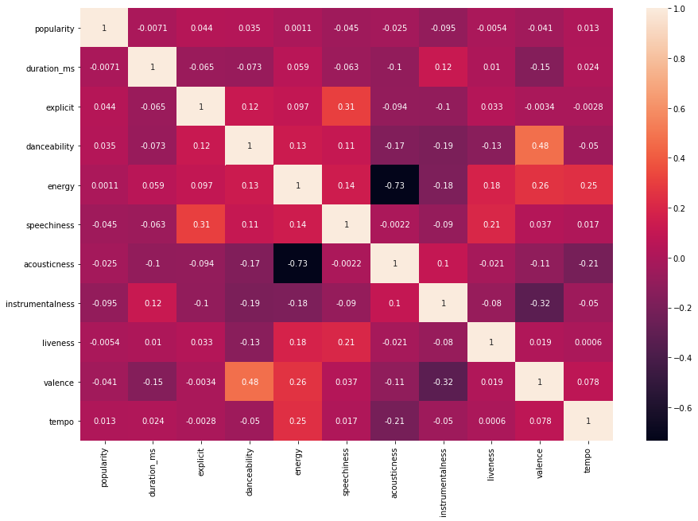

```python
plt.figure(figsize=(15,10))
sns.heatmap(data=df.corr(),annot=True)
plt.show()
```

### Acousticness and Energy are very less i.e more than 70% corelated to each other. But valence and danceability are nearly 50% corelated to each other.

## Show the records which contains slow tempo(60 -76)

```python
df[(df['tempo'] < 76) & (df['tempo'] > 60)]
```

[output not shown]

4063 rows × 15 columns

## Show artists whose songs are having explicit tags(E).

```python
df[df['explicit']==1]['artists']
```

```
sr_no
59            Chord Overstreet
243                Days N Daze
247                   Get Dead
284       Andrew Foy;Renee Foy
298                Days N Daze
                  ...
112963                  Ati242
112965                    Rota
112972                    Rota
112976                   Hidra
112983            Contra;İtaat
Name: artists, Length: 9747, dtype: object
```

## Show a worthy chart for explicit songs.

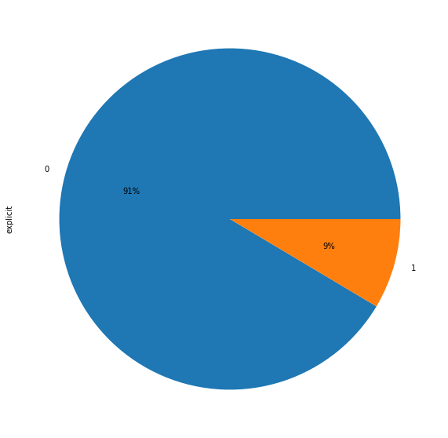

```python
p=df['explicit'].value_counts()
plt.figure(figsize=(10,10))
p.plot(kind='pie',autopct='%.f%%')
plt.show()
```

### Above observation of pie chart shows 91% songs are not explicit with 0 and 9% songs are explicit with 1.

## Show records that are having greatest number of popularity

```python
df[df['popularity']==df['popularity'].max()]
```

| sr_no | artists | album_name | track_name | popularity | duration_ms | explicit | danceability | energy | speechiness | acousticness | instrumentalness | liveness | valence | tempo | track_genre |
| --- | --- | --- | --- | --- | --- | --- | --- | --- | --- | --- | --- | --- | --- | --- | --- |
| 20001 | Sam Smith;Kim Petras | Unholy (feat. Kim Petras) | Unholy (feat. Kim Petras) | 100 | 156.943 | 0 | 0.714 | 0.472 | 0.0864 | 0.013 | 0.000005 | 0.266 | 0.238 | 131.121 | dance |
| 81051 | Sam Smith;Kim Petras | Unholy (feat. Kim Petras) | Unholy (feat. Kim Petras) | 100 | 156.943 | 0 | 0.714 | 0.472 | 0.0864 | 0.013 | 0.000005 | 0.266 | 0.238 | 131.121 | pop |

### Artists Sam Smith;Kim Petras are having greatest number of popularity.

## Show top 5 artists with highest popularity using visualization plot.

```python
df1=df.sort_values(by='popularity', ascending=False)[:5]
df1
```

| sr_no | artists | album_name | track_name | popularity | duration_ms | explicit | danceability | energy | speechiness | acousticness | instrumentalness | liveness | valence | tempo | track_genre |
| --- | --- | --- | --- | --- | --- | --- | --- | --- | --- | --- | --- | --- | --- | --- | --- |
| 20001 | Sam Smith;Kim Petras | Unholy (feat. Kim Petras) | Unholy (feat. Kim Petras) | 100 | 156.943 | 0 | 0.714 | 0.472 | 0.0864 | 0.01300 | 0.000005 | 0.266 | 0.238 | 131.121 | dance |
| 81051 | Sam Smith;Kim Petras | Unholy (feat. Kim Petras) | Unholy (feat. Kim Petras) | 100 | 156.943 | 0 | 0.714 | 0.472 | 0.0864 | 0.01300 | 0.000005 | 0.266 | 0.238 | 131.121 | pop |
| 51664 | Bizarrap;Quevedo | Quevedo: Bzrp Music Sessions, Vol. 52 | Quevedo: Bzrp Music Sessions, Vol. 52 | 99 | 198.937 | 0 | 0.621 | 0.782 | 0.0440 | 0.01250 | 0.033000 | 0.230 | 0.550 | 128.033 | hip-hop |
| 89411 | Manuel Turizo | La Bachata | La Bachata | 98 | 162.637 | 0 | 0.835 | 0.679 | 0.0364 | 0.58300 | 0.000002 | 0.218 | 0.850 | 124.980 | reggaeton |
| 81210 | David Guetta;Bebe Rexha | I'm Good (Blue) | I'm Good (Blue) | 98 | 175.238 | 1 | 0.561 | 0.965 | 0.0343 | 0.00383 | 0.000007 | 0.371 | 0.304 | 128.040 | pop |

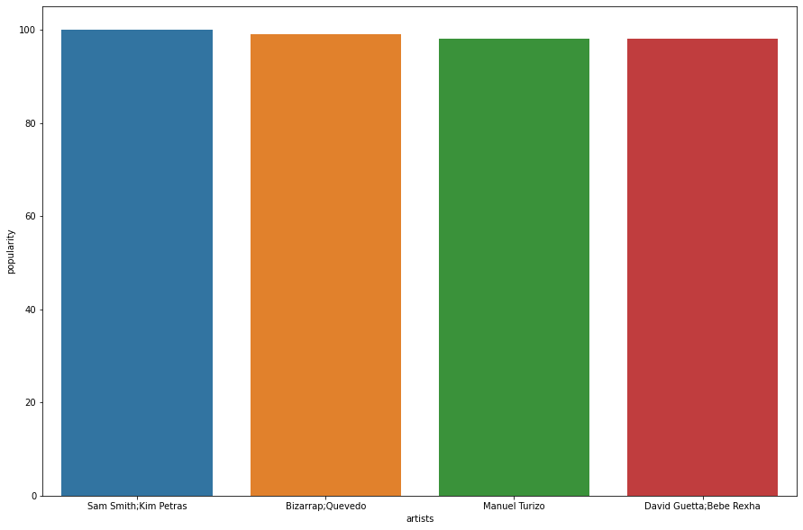

```python
plt.figure(figsize=(15,10))
sns.barplot(x=df1['artists'],y=df1['popularity'])
plt.show()
```

### As we can observe Sam Smith and Kim Petras both are having 100 popularity 2 times(because of two genres dance and pop). Hence above barplot shows only 4 records.

```python
d=df[(df['tempo']>60) & (df['tempo']<76)]
r=d.sample(10)
r['track_name']
```

```
sr_no
16027     Weihnachtsoratorium, BWV 248: Nr. 9 Choral "Ac...
97847     Pot-Pourri: De Igual Pra Igual / Frente a Fren...
64355           The Christmas Song (Merry Christmas To You)
77826                                             Sem Razão
93639                                          O, pozabud'!
75968                                        Inside Passage
111900                               Killer – A COLORS SHOW
106037                                        Little Things
47980                                                Exitus
101467                                       Slumbery Notes
Name: track_name, dtype: object
```

## Visualise above solution using relevant graph.

[figure not shown]

```python
plt.figure(figsize=(15,10))
plt.barh(r['track_name'],r['tempo'],color='y')
plt.xlabel('Tempo in BPM')
plt.ylabel('Track/Songs Names')
plt.show()
```

### Above graph shows horizontal bars for 10 random song/track names.

## Show corelation between popularity and duration of songs.

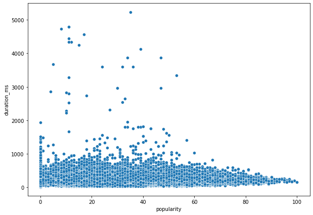

```python
plt.figure(figsize=(10,7))
sns.scatterplot(x=df['popularity'], y=df['duration_ms'])
plt.show()
```

### Majority of popular songs are having duration between 0 and 1000 duration. Only one song is above 5000 duration.

## Show frequency distribution and smooth curve for valence.

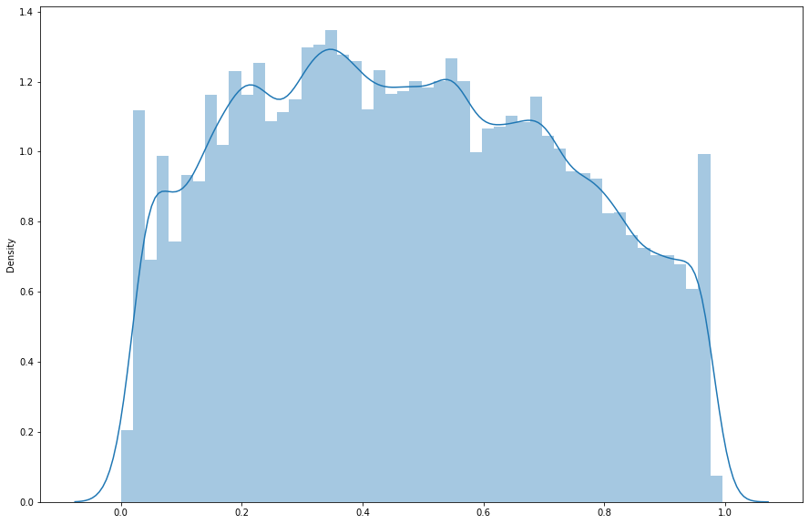

```python
plt.figure(figsize=(15,10))
sns.distplot(x=df['valence'])
plt.show()
```

### Frequency of valence is highly distributed between 0.2 and 0.4 bins of distplot.